# Intro to Point Pattern Analysis using R and QGIS

Corey Sparks, Ph.D.

02 March, 2022

This example shows how to use R and QGIS from within R to perform a series of common point pattern analysis techniques.

```r
library(mapview)
library(sf)
library(censusxy)
library(dplyr)
```

## Create point layer from grocery data from AtoZdatabase

#### just use the lat / long information in the data!

```r
addr<-read.csv(url("https://raw.githubusercontent.com/coreysparks/DEM7093/main/data/west_side_groceries.csv"))
addr <- addr%>%
  dplyr::select(names(addr)[c(4,6,14,23:24,41,42)])

results <- st_as_sf(addr, coords=c("Longitude", "Latitude"), crs=4269,agr="constant")

results.proj<-st_transform(results,
                           crs = 2278)
```

```r
mv1 <- mapview(results.proj)
mapshot(mv1, file = paste0(getwd(), "/map1.png"))
```

```
## PhantomJS not found. You can install it with webshot::install_phantomjs(). If it is installed, please make sure the phantomjs executable can be found via the PATH variable.
```

```r
mv1
```

[interactive chart not shown]

```r
library(tmap)
library(tmaptools)
library(OpenStreetMap)
bg<-  read_osm(results.proj, ext=1.1)

tmap_mode("view")
```

```
## tmap mode set to interactive viewing
```

```r
tm_basemap("OpenStreetMap.Mapnik")+
  tm_shape(results.proj)+
  tm_dots()
```

[interactive chart not shown]

```r
tmap_mode("plot")
```

```
## tmap mode set to plotting
```

```r
library(ggplot2)
library(ggmap)
library(ggspatial)
library(leaflet)
leaflet() %>%
  addTiles()%>%
  addMarkers(lng = addr$Longitude, lat= addr$Latitude)
```

[interactive chart not shown]

# mean feature - average of coordinates

```r
mean_feature<-apply(st_coordinates(results.proj), MARGIN = 2, FUN = mean)
mean_feature<-data.frame(place="meanfeature", x=mean_feature[1], y= mean_feature[2])
mean_feature<-st_as_sf(mean_feature, coords = c("x", "y"), crs= 2278)


tmap_mode("view")
```

```
## tmap mode set to interactive viewing
```

```r
tm_basemap("OpenStreetMap.Mapnik")+
  tm_shape(results.proj, size = .2)+
  tm_dots(col = "green")+
  tm_shape(mean_feature)+
  tm_dots(col = "red", size = .2)
```

[interactive chart not shown]

## Central feature - Median of coordinates

```r
median_feature<-apply(st_coordinates(results.proj),
                      MARGIN = 2,
                      FUN = median)

median_feature<-data.frame(place="medianfeature",
                           x=median_feature[1],
                           y= median_feature[2])

median_feature<-st_as_sf(median_feature,
                         coords = c("x", "y"),
                         crs= 2278)


tmap_mode("view")
```

```
## tmap mode set to interactive viewing
```

```r
tm_basemap("OpenStreetMap.Mapnik")+
  tm_shape(results.proj)+
  tm_dots(col = "green", size = .2)+
  tm_shape(mean_feature)+
  tm_dots(col = "red", size=.2)+
  tm_shape(median_feature)+
  tm_dots(col = "blue", size = .2)
```

[interactive chart not shown]

## Buffer points

```r
grocery_buff<- st_buffer(results.proj, dist = 1000)

#tmap_mode("plot")
tm_basemap("OpenStreetMap.Mapnik" )+
  tm_shape(results.proj, is.master = T)+
  tm_dots(col = "green")+
  tm_shape(grocery_buff)+
  tm_polygons(col = "red", alpha = .1)
```

[interactive chart not shown]

## Convex hull plot

```r
chull <- st_convex_hull(st_union(results))

tmap_mode("view")
```

```
## tmap mode set to interactive viewing
```

```r
tm_basemap("OpenStreetMap.Mapnik")+
  tm_shape(results.proj)+
  tm_dots(col = "green")+
  tm_shape(chull)+
  tm_polygons(col = "grey", alpha = .5)
```

[interactive chart not shown]

## kernel density -

### You need projected data for this to work right

R can do kernel density maps, but using simple features it’s kind of complicated. Here is one way to do this using the `SpatialKDE` package:

```r
library(SpatialKDE)

grid_groc <- results.proj %>%
  create_grid_rectangular(cell_size = 1000, side_offset = 2000)

kde <- results.proj%>%
  kde(band_width = 2000, kernel= "quartic", grid = grid_groc)

tm_shape(kde)+
  tm_polygons(col = "kde_value", palette= "viridis", title = "Density Estimate")+
  tm_shape(results.proj)+
  tm_dots()
```

[interactive chart not shown]

Alternatively, you can use Qgis through R instead using the `qgisprocess` [package](https://github.com/paleolimbot/qgisprocess)

```r
library(qgisprocess)
qgis_configure()
```

```
## Trying getOption('qgisprocess.path'): 'C:/Program Files/QGIS 3.16.16/bin/qgis_process-qgis-ltr.bat'
```

```
## Success!
```

```
## QGIS version: 3.16.16-Hannover
```

```
## Saving configuration to 'C:\Users\ozd504\AppData\Local/R-qgisprocess/R-qgisprocess/Cache/cache-0.0.0.9000.rds'
```

```
## Metadata of 1210 algorithms queried and stored in cache.
## Run `qgis_algorithms()` to see them.
```

```
## - Using JSON for output serialization
```

To use this, we need to find the name of the Qgis algorithm we want. `qgis_algorithms()` can return all available algorithms, then we can either filter it with `View()` or use grep to search for one.

```r
algs<-qgis_algorithms()
algs[grepl(pattern = "density", x = algs$algorithm ),]
```

| provider | provider_title | algorithm | algorithm_id | algorithm_title | provider_id | can_cancel | deprecated | group | has_known_issues | help_url | name | requires_matching_crs | short_description | tags | provider_can_be_activated | default_raster_file_extension | default_vector_file_extension | provider_is_active | provider_long_name | provider_name | supported_output_raster_extensions | supported_output_table_extensions | supported_output_vector_extensions | supports_non_file_based_output | provider_version | provider_warning |
| --- | --- | --- | --- | --- | --- | --- | --- | --- | --- | --- | --- | --- | --- | --- | --- | --- | --- | --- | --- | --- | --- | --- | --- | --- | --- | --- |
| grass7 | GRASS | grass7:r.li.edgedensity | r.li.edgedensity | r.li.edgedensity | grass7 | TRUE | FALSE | Raster (r.*) | FALSE | https://grass.osgeo.org/grass78/manuals/r.li.edgedensity.html | r.li.edgedensity | FALSE | Calculates edge density index on a raster map, using a 4 neighbour algorithm |  | FALSE | tif | gpkg | TRUE | GRASS GIS (7.8.6) | GRASS |  |  |  | FALSE | NA | NA |
| grass7 | GRASS | grass7:r.li.edgedensity.ascii | r.li.edgedensity.ascii | r.li.edgedensity.ascii | grass7 | TRUE | FALSE | Raster (r.*) | FALSE | https://grass.osgeo.org/grass78/manuals/r.li.edgedensity.html | r.li.edgedensity.ascii | FALSE | r.li.edgedensity.ascii - Calculates edge density index on a raster map, using a 4 neighbour algorithm |  | FALSE | tif | gpkg | TRUE | GRASS GIS (7.8.6) | GRASS |  |  |  | FALSE | NA | NA |
| grass7 | GRASS | grass7:r.li.patchdensity | r.li.patchdensity | r.li.patchdensity | grass7 | TRUE | FALSE | Raster (r.*) | FALSE | https://grass.osgeo.org/grass78/manuals/r.li.patchdensity.html | r.li.patchdensity | FALSE | Calculates patch density index on a raster map, using a 4 neighbour algorithm |  | FALSE | tif | gpkg | TRUE | GRASS GIS (7.8.6) | GRASS |  |  |  | FALSE | NA | NA |
| grass7 | GRASS | grass7:r.li.patchdensity.ascii | r.li.patchdensity.ascii | r.li.patchdensity.ascii | grass7 | TRUE | FALSE | Raster (r.*) | FALSE | https://grass.osgeo.org/grass78/manuals/r.li.patchdensity.html | r.li.patchdensity.ascii | FALSE | r.li.patchdensity.ascii - Calculates patch density index on a raster map, using a 4 neighbour algorithm |  | FALSE | tif | gpkg | TRUE | GRASS GIS (7.8.6) | GRASS |  |  |  | FALSE | NA | NA |
| native | QGIS (native c++) | native:linedensity | linedensity | Line density | native | TRUE | FALSE | Interpolation | FALSE | NA | Line density | FALSE | NA |  | TRUE | tif | gpkg | TRUE | QGIS (native c++) | QGIS (native c++) |  |  |  | TRUE | NA | NA |
| qgis | QGIS | qgis:heatmapkerneldensityestimation | heatmapkerneldensityestimation | Heatmap (Kernel Density Estimation) | qgis | TRUE | FALSE | Interpolation | FALSE | NA | Heatmap (Kernel Density Estimation) | FALSE | NA |  | TRUE | tif | gpkg | TRUE | QGIS | QGIS |  |  |  | TRUE | NA | NA |
| r | R | r:Kernel_density_estimation | Kernel_density_estimation | Kernel density estimation | r | TRUE | FALSE | Basic statistics | FALSE | NA | Kernel density estimation | FALSE | C:\\Users\\ozd504\\AppData\\Roaming\\QGIS\\QGIS3\\profiles\\default\\processing\\rscripts\\Kernel_density_estimation.rsx |  | TRUE | tif | gpkg | TRUE | R | R |  |  |  | FALSE | QGIS R Provider version 3.0.0, R version 4.1.2 (2021-11-01) -- "Bird Hippie"\n | NA |
| saga | SAGA | saga:fragmentationclassesfromdensityandconnectivity | fragmentationclassesfromdensityandconnectivity | Fragmentation Classes from Density and Connectivity | saga | TRUE | FALSE | Raster - Analysis | FALSE | NA | Fragmentation Classes from Density and Connectivity | FALSE | NA |  | TRUE | sdat | shp | TRUE | SAGA (7.8.2) | SAGA |  |  |  | FALSE | NA | SAGA version 7.8.2 is not officially supported - algorithms may encounter issues |
| saga | SAGA | saga:kerneldensityestimation | kerneldensityestimation | Kernel Density Estimation | saga | TRUE | FALSE | Raster - Rasterizing | FALSE | NA | Kernel Density Estimation | FALSE | NA |  | TRUE | sdat | shp | TRUE | SAGA (7.8.2) | SAGA |  |  |  | FALSE | NA | SAGA version 7.8.2 is not officially supported - algorithms may encounter issues |

```r
qgis_show_help("qgis:heatmapkerneldensityestimation")
```

```
## Heatmap (Kernel Density Estimation) (qgis:heatmapkerneldensityestimation)
##
## ----------------
## Description
## ----------------
##
## ----------------
## Arguments
## ----------------
##
## INPUT: Point layer
##  Argument type:  source
##  Acceptable values:
##      - Path to a vector layer
## RADIUS: Radius
##  Argument type:  distance
##  Acceptable values:
##      - A numeric value
## RADIUS_FIELD: Radius from field
##  Argument type:  field
##  Acceptable values:
##      - The name of an existing field
##      - ; delimited list of existing field names
## PIXEL_SIZE: Output raster size
##  Argument type:  number
##  Acceptable values:
##      - A numeric value
## WEIGHT_FIELD: Weight from field
##  Argument type:  field
##  Acceptable values:
##      - The name of an existing field
##      - ; delimited list of existing field names
## KERNEL: Kernel shape
##  Argument type:  enum
##  Available values:
##      - 0: Quartic
##      - 1: Triangular
##      - 2: Uniform
##      - 3: Triweight
##      - 4: Epanechnikov
```

[output cut: 11 more lines]

```
##      - 1: Scaled
##  Acceptable values:
##      - Number of selected option, e.g. '1'
##      - Comma separated list of options, e.g. '1,3'
## OUTPUT: Heatmap
##  Argument type:  rasterDestination
##  Acceptable values:
##      - Path for new raster layer
##
## ----------------
## Outputs
## ----------------
##
## OUTPUT: <outputRaster>
##  Heatmap
```

Run the algorithm

```r
wic_dens<-qgis_run_algorithm(algorithm ="qgis:heatmapkerneldensityestimation",
         INPUT=results.proj,
         RADIUS = 2000,
         PIXEL_SIZE = 100,
         KERNEL = 0,
         OUTPUT=file.path(getwd(), "wicdenst.TIF"),
         load_output = TRUE)
```

```
## Ignoring unknown input 'load_output'
```

```
## Argument `RADIUS_FIELD` is unspecified (using QGIS default value).
```

```
## Argument `WEIGHT_FIELD` is unspecified (using QGIS default value).
```

```
## Argument `DECAY` is unspecified (using QGIS default value).
```

```
## Using `OUTPUT_VALUE = "Raw"`
```

```
## Running cmd.exe /c call \
##   "C:/Program Files/QGIS 3.16.16/bin/qgis_process-qgis-ltr.bat" --json run \
##   "qgis:heatmapkerneldensityestimation" \
##   "--INPUT=C:\Users\ozd504\AppData\Local\Temp\RtmpKei7eU\file53e4439f4a68\file53e45ba673ee.gpkg" \
##   "--RADIUS=2000" "--PIXEL_SIZE=100" "--KERNEL=0" "--OUTPUT_VALUE=0" \
##   "--OUTPUT=C:/Users/ozd504/Github/DEM7093/code/wicdenst.TIF"
```

```r
library(raster)
library(RColorBrewer)

result<- qgis_as_raster(wic_dens)

projection(result)<-crs(results.proj)

tmap_mode("view")
```

```
## tmap mode set to interactive viewing
```

```r
tm_basemap("OpenStreetMap.Mapnik")+
  tm_shape(result)+
  tm_raster()+
  tm_shape(results.proj, is.master = T)+
  tm_dots(col="red")
```

[interactive chart not shown]

## Spatial join

```r
library(tidycensus)

#load census tract data
sa_acs<-get_acs(geography = "tract",
                state="TX",
                county = "Bexar",
                year = 2019,
                variables=c( "DP05_0001E", "DP03_0062E",
                             "DP03_0119PE","DP02_0066PE",
                             "DP03_0062E","DP03_0119PE",
                             "DP05_0073PE","DP05_0066PE") ,
                geometry = T, output = "wide")
#rename variables and filter missing cases
sa_acs2<-sa_acs%>%
  mutate(totpop= DP05_0001E,
         pblack=DP05_0073PE,
         phisp=DP05_0066PE,
         phsormore=DP02_0066PE,
         medhhinc=DP03_0062E,
         ppov=DP03_0119PE)%>%
  dplyr::select(GEOID, totpop, pblack, phisp, medhhinc, ppov)

sa_acs2<-st_transform(sa_acs2, crs = 2278)
sa_trol<-st_cast(sa_acs2, "MULTILINESTRING") #make outline
```

```r
spjoin<-st_join(results.proj, sa_acs2)
#head(spjoin)

tmap_mode("view")
```

```
## tmap mode set to interactive viewing
```

```r
tm_basemap("OpenStreetMap.Mapnik")+
  tm_shape(spjoin, is.master = T)+
  tm_dots("ppov", size = .1)+
  tm_shape(sa_acs2)+
  tm_polygons(alpha = .1)
```

[interactive chart not shown]

## Count points in polygons

Point in polygon operations are actually a spatial intersection (more on this next week!) where we see how many points fall within a given polygon.

```r
sa_acs2$ngroc<- lengths(st_intersects(sa_acs2, results.proj))

sa_acs2$groc_pc <- 1000*(sa_acs2$ngroc/sa_acs2$totpop)

tmap_mode("plot")
```

```
## tmap mode set to plotting
```

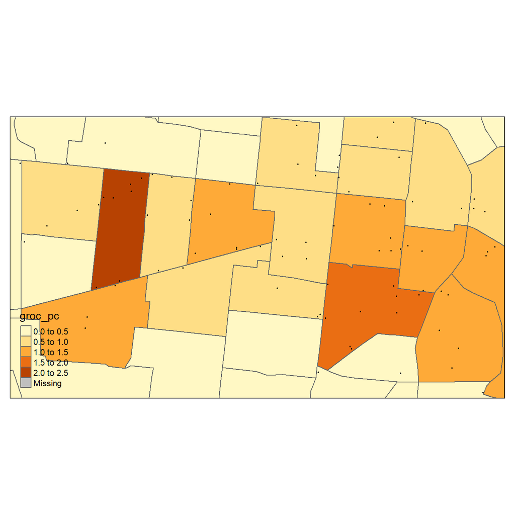

```r
m<-tm_basemap("OpenStreetMap.Mapnik")+
  tm_shape(sa_acs2)+
  tm_polygons("groc_pc")+
  tm_shape(spjoin, is.master = T)+
  tm_dots( size = .01)

m
```

## Thiessen/Voronoi Polygons

Thiessen or Voronoi polygons are a process where we can convert points into polygons. I use QGIS to do this, R has issues.

```r
algs[grepl(pattern = "voronoi", x = algs$algorithm ),]
```

| provider | provider_title | algorithm | algorithm_id | algorithm_title | provider_id | can_cancel | deprecated | group | has_known_issues | help_url | name | requires_matching_crs | short_description | tags | provider_can_be_activated | default_raster_file_extension | default_vector_file_extension | provider_is_active | provider_long_name | provider_name | supported_output_raster_extensions | supported_output_table_extensions | supported_output_vector_extensions | supports_non_file_based_output | provider_version | provider_warning |
| --- | --- | --- | --- | --- | --- | --- | --- | --- | --- | --- | --- | --- | --- | --- | --- | --- | --- | --- | --- | --- | --- | --- | --- | --- | --- | --- |
| grass7 | GRASS | grass7:v.voronoi | v.voronoi | v.voronoi | grass7 | TRUE | FALSE | Vector (v.*) | FALSE | https://grass.osgeo.org/grass78/manuals/v.voronoi.html | v.voronoi | FALSE | v.voronoi - Creates a Voronoi diagram from an input vector layer containing points. |  | FALSE | tif | gpkg | TRUE | GRASS GIS (7.8.6) | GRASS |  |  |  | FALSE | NA | NA |
| grass7 | GRASS | grass7:v.voronoi.skeleton | v.voronoi.skeleton | v.voronoi.skeleton | grass7 | TRUE | FALSE | Vector (v.*) | FALSE | https://grass.osgeo.org/grass78/manuals/v.voronoi.html | v.voronoi.skeleton | FALSE | v.voronoi.skeleton - Creates a Voronoi diagram for polygons or compute the center line/skeleton of polygons. |  | FALSE | tif | gpkg | TRUE | GRASS GIS (7.8.6) | GRASS |  |  |  | FALSE | NA | NA |
| qgis | QGIS | qgis:voronoipolygons | voronoipolygons | Voronoi polygons | qgis | TRUE | FALSE | Vector geometry | FALSE | NA | Voronoi polygons | FALSE | NA |  | TRUE | tif | gpkg | TRUE | QGIS | QGIS |  |  |  | TRUE | NA | NA |

```r
qgis_show_help("qgis:voronoipolygons")
```

```
## Voronoi polygons (qgis:voronoipolygons)
##
## ----------------
## Description
## ----------------
## This algorithm takes a points layer and generates a polygon layer containing the voronoi polygons corresponding to those input points.
##
##
## ----------------
## Arguments
## ----------------
##
## INPUT: Input layer
##  Argument type:  source
##  Acceptable values:
##      - Path to a vector layer
## BUFFER: Buffer region (% of extent)
##  Argument type:  number
##  Acceptable values:
##      - A numeric value
## OUTPUT: Voronoi polygons
##  Argument type:  sink
##  Acceptable values:
##      - Path for new vector layer
##
## ----------------
## Outputs
## ----------------
##
## OUTPUT: <outputVector>
##  Voronoi polygons
```

```r
wic_von<-qgis_run_algorithm(alg="qgis:voronoipolygons",
         INPUT=results.proj,
         OUTPUT=file.path(tempdir(), "wicvon.shp"),
         load_output = TRUE)

wic_von<-sf::read_sf(qgis_output(wic_von, "OUTPUT"))

tmap_mode("view")
map1<-tm_basemap("OpenStreetMap.Mapnik")+
  tm_shape(wic_von)+
  tm_polygons(col="grey", alpha=.4)+
  tm_shape(results.proj)+
  tm_dots( size = .01)


# plot map
map1
```

[output not shown]

## Nearest Neighbor analysis

Nearest neighbor analysis is used to test if a pattern of points is distrubuted randomly or clustered.

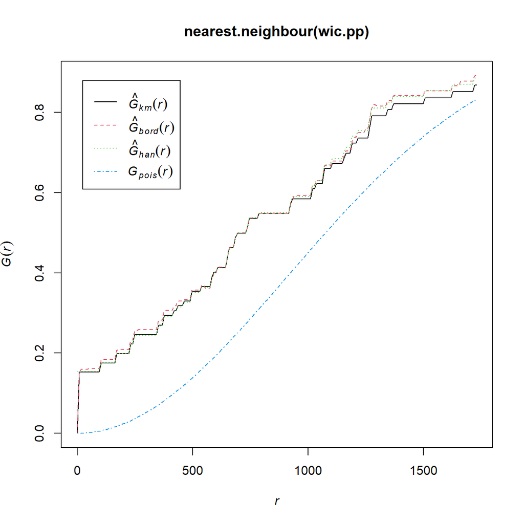

```r
library(spatstat)
wic.pp<-as.ppp(as(results.proj, "Spatial"))

plot(nearest.neighbour(wic.pp))
```

```r
algs[grepl(pattern = "nearest", x = algs$algorithm ),]
```

| provider | provider_title | algorithm | algorithm_id | algorithm_title | provider_id | can_cancel | deprecated | group | has_known_issues | help_url | name | requires_matching_crs | short_description | tags | provider_can_be_activated | default_raster_file_extension | default_vector_file_extension | provider_is_active | provider_long_name | provider_name | supported_output_raster_extensions | supported_output_table_extensions | supported_output_vector_extensions | supports_non_file_based_output | provider_version | provider_warning |
| --- | --- | --- | --- | --- | --- | --- | --- | --- | --- | --- | --- | --- | --- | --- | --- | --- | --- | --- | --- | --- | --- | --- | --- | --- | --- | --- |
| gdal | GDAL | gdal:gridinversedistancenearestneighbor | gridinversedistancenearestneighbor | Grid (IDW with nearest neighbor searching) | gdal | FALSE | FALSE | Raster analysis | FALSE | NA | Grid (IDW with nearest neighbor searching) | FALSE | NA |  | TRUE | tif | gpkg | TRUE | GDAL (3.4.1) | GDAL |  |  |  | FALSE | NA | NA |
| gdal | GDAL | gdal:gridnearestneighbor | gridnearestneighbor | Grid (Nearest neighbor) | gdal | FALSE | FALSE | Raster analysis | FALSE | NA | Grid (Nearest neighbor) | FALSE | NA |  | TRUE | tif | gpkg | TRUE | GDAL (3.4.1) | GDAL |  |  |  | FALSE | NA | NA |
| native | QGIS (native c++) | native:angletonearest | angletonearest | Align points to features | native | TRUE | FALSE | Cartography | FALSE | NA | Align points to features | FALSE | Rotates point features to align them to nearby features. |  | TRUE | tif | gpkg | TRUE | QGIS (native c++) | QGIS (native c++) |  |  |  | TRUE | NA | NA |
| native | QGIS (native c++) | native:joinbynearest | joinbynearest | Join attributes by nearest | native | TRUE | FALSE | Vector general | FALSE | NA | Join attributes by nearest | FALSE | Joins a layer to another layer, using the closest features (nearest neighbors). |  | TRUE | tif | gpkg | TRUE | QGIS (native c++) | QGIS (native c++) |  |  |  | TRUE | NA | NA |
| native | QGIS (native c++) | native:nearestneighbouranalysis | nearestneighbouranalysis | Nearest neighbour analysis | native | TRUE | FALSE | Vector analysis | FALSE | NA | Nearest neighbour analysis | FALSE | NA |  | TRUE | tif | gpkg | TRUE | QGIS (native c++) | QGIS (native c++) |  |  |  | TRUE | NA | NA |
| qgis | QGIS | qgis:distancetonearesthublinetohub | distancetonearesthublinetohub | Distance to nearest hub (line to hub) | qgis | TRUE | FALSE | Vector analysis | FALSE | NA | Distance to nearest hub (line to hub) | FALSE | NA |  | TRUE | tif | gpkg | TRUE | QGIS | QGIS |  |  |  | TRUE | NA | NA |
| qgis | QGIS | qgis:distancetonearesthubpoints | distancetonearesthubpoints | Distance to nearest hub (points) | qgis | TRUE | FALSE | Vector analysis | FALSE | NA | Distance to nearest hub (points) | FALSE | NA |  | TRUE | tif | gpkg | TRUE | QGIS | QGIS |  |  |  | TRUE | NA | NA |
| qgis | QGIS | qgis:knearestconcavehull | knearestconcavehull | Concave hull (k-nearest neighbor) | qgis | TRUE | FALSE | Vector geometry | FALSE | NA | Concave hull (k-nearest neighbor) | FALSE | Creates a concave hull using the k-nearest neighbor algorithm. |  | TRUE | tif | gpkg | TRUE | QGIS | QGIS |  |  |  | TRUE | NA | NA |
| saga | SAGA | saga:nearestneighbour | nearestneighbour | Nearest Neighbour | saga | TRUE | FALSE | Raster - Rasterizing | FALSE | NA | Nearest Neighbour | FALSE | NA |  | TRUE | sdat | shp | TRUE | SAGA (7.8.2) | SAGA |  |  |  | FALSE | NA | SAGA version 7.8.2 is not officially supported - algorithms may encounter issues |

```r
qgis_show_help("native:nearestneighbouranalysis")
```

```
## Nearest neighbour analysis (native:nearestneighbouranalysis)
##
## ----------------
## Description
## ----------------
## This algorithm performs nearest neighbor analysis for a point layer.
##
## The output describes how the data are distributed (clustered, randomly or distributed).
##
## Output is generated as an HTML file with the computed statistical values.
##
## ----------------
## Arguments
## ----------------
##
## INPUT: Input layer
##  Argument type:  source
##  Acceptable values:
##      - Path to a vector layer
## OUTPUT_HTML_FILE: Nearest neighbour
##  Argument type:  fileDestination
##  Acceptable values:
##      - Path for new file
##
## ----------------
## Outputs
## ----------------
##
## OUTPUT_HTML_FILE: <outputHtml>
##  Nearest neighbour
## OBSERVED_MD: <outputNumber>
##  Observed mean distance
## EXPECTED_MD: <outputNumber>
##  Expected mean distance
## NN_INDEX: <outputNumber>
##  Nearest neighbour index
## POINT_COUNT: <outputNumber>
##  Number of points
## Z_SCORE: <outputNumber>
##  Z-score
```

Here I use QGIS to get a single test of the randomness

```r
wic_nn<-qgis_run_algorithm(alg="native:nearestneighbouranalysis",
         INPUT=results.proj,
        OUTPUT_HTML_FILE=file.path(tempdir(), "wicnn.html"),
         load_output = TRUE)
```

```
## Ignoring unknown input 'load_output'
```

```
## Running cmd.exe /c call \
##   "C:/Program Files/QGIS 3.16.16/bin/qgis_process-qgis-ltr.bat" --json run \
##   "native:nearestneighbouranalysis" \
##   "--INPUT=C:\Users\ozd504\AppData\Local\Temp\RtmpKei7eU\file53e4439f4a68\file53e413434127.gpkg" \
##   "--OUTPUT_HTML_FILE=C:\Users\ozd504\AppData\Local\Temp\RtmpKei7eU/wicnn.html"
```

```r
wic_nn
```

```
## <Result of `qgis_run_algorithm("native:nearestneighbouranalysis", ...)`>
## List of 6
##  $ EXPECTED_MD     : num 1145
##  $ NN_INDEX        : num 0.812
##  $ OBSERVED_MD     : num 930
##  $ OUTPUT_HTML_FILE: 'qgis_outputHtml' chr "C:\\Users\\ozd504\\AppData\\Local\\Temp\\RtmpKei7eU/wicnn.html"
##  $ POINT_COUNT     : num 92
##  $ Z_SCORE         : num -3.45
```